# Machine Learning Final Project - Human Activity Recognition

Terry Wang

9/10/2017

# Executive Summary

# Source

The data is from http://groupware.les.inf.puc-rio.br/har. Big thanks to them for making the data available.

# Loading and Cleaning Data

The data is first downloaded from the following links:

```r
training <- read.csv("https://d396qusza40orc.cloudfront.net/predmachlearn/pml-training.csv")
testing <- read.csv("https://d396qusza40orc.cloudfront.net/predmachlearn/pml-testing.csv")
```

Afterwards, we take out all of the columns that are either NAs or are not predictors.

```r
n <- which(sapply(testing, function(x) all(is.na(x))))
train1 <- training[, -n]
test1 <- testing[, -n]

train1 <- train1[, -c(1:7)]
test1 <- test1[, -c(1:7)]
```

# Exploring the Data

Our training data has 19622 observations while our test data has only 20 observations, with 52 predictors.

We can also make a table of the outcome variable in the training data:

```r
table(train1$classe)
```

```
##
##    A    B    C    D    E
## 5580 3797 3422 3216 3607
```

We can see that outcome class A is overrepresented in the training data, but otherwise we don’t have a major problem with having not enough observations for a particular outcome or skewed distribution of outcomes.

# The Prediction Algorithm and Cross Validation

I decided to predict the outcome using the random forest algorithm with 501 trees because it is a tried and true tool for classification problems. I also decided to use a 3-fold cross validation technique to assess the out-of-sample error rate of the prediction algorithm. We will divide the training data into 3 folds and validate the prediction algorithm.

```r
folds <- createFolds(y = train1$classe, k = 3, list = FALSE)
train_fold1 <- train1[folds!=1, ]
test_fold1 <- train1[folds==1, ]
train_fold2 <- train1[folds!=2, ]
test_fold2 <- train1[folds==2, ]
train_fold3 <- train1[folds!=3, ]
test_fold3 <- train1[folds==3, ]

rf1 <- randomForest(x = train_fold1[,c(1:52)], y = train_fold1$classe, xtest = test_fold1[,c(1:52)], ytest = test_fold1$classe, ntree = 501)
rf2 <- randomForest(x = train_fold2[,c(1:52)], y = train_fold2$classe, xtest = test_fold2[,c(1:52)], ytest = test_fold2$classe, ntree = 501)
rf3 <- randomForest(x = train_fold3[,c(1:52)], y = train_fold3$classe, xtest = test_fold3[,c(1:52)], ytest = test_fold3$classe, ntree = 501)
```

To find out whether 501 trees is a good number to use, we can plot the oob error rate against the number of trees. To use as an example, we will plot this graph for rf1, or the random forest algorithm for the first fold:

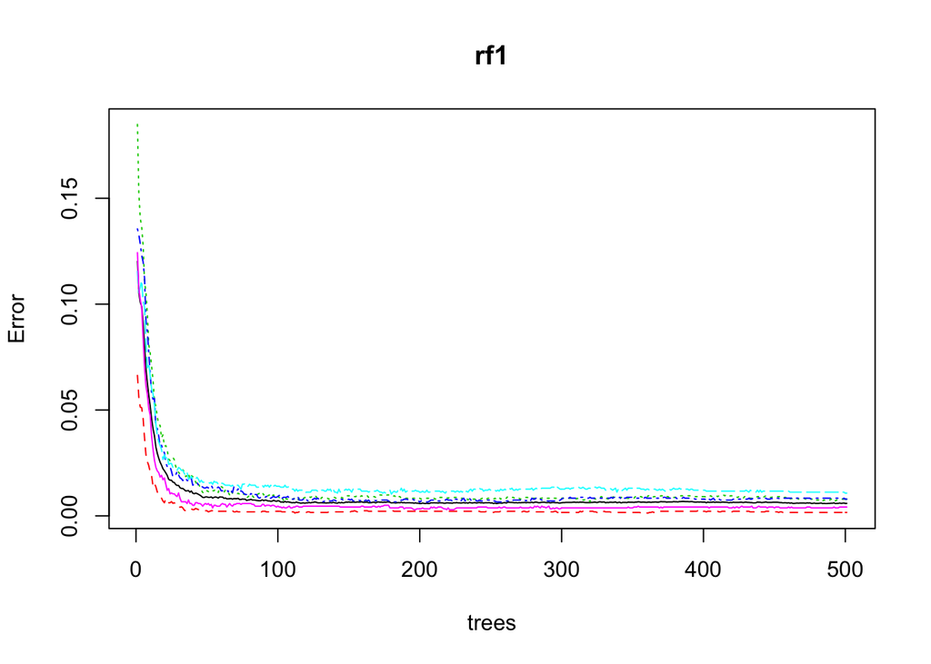

```r
plot(rf1)
```

We next look at the confusion matrix of the first fold and we observe the following:

```r
rf1
```

```
##
## Call:
##  randomForest(x = train_fold1[, c(1:52)], y = train_fold1$classe,      xtest = test_fold1[, c(1:52)], ytest = test_fold1$classe,      ntree = 501)
##                Type of random forest: classification
##                      Number of trees: 501
## No. of variables tried at each split: 7
##
##         OOB estimate of  error rate: 0.59%
## Confusion matrix:
##      A    B    C    D    E class.error
## A 3714    4    1    0    1 0.001612903
## B   13 2512    7    0    0 0.007898894
## C    0   14 2263    4    0 0.007891276
## D    0    0   22 2121    1 0.010727612
## E    0    0    1    9 2394 0.004159734
##                 Test set error rate: 0.52%
## Confusion matrix:
##      A    B    C    D    E  class.error
## A 1853    0    7    0    0 0.0037634409
## B    5 1259    1    0    0 0.0047430830
## C    0    7 1134    0    0 0.0061349693
## D    0    0   13 1059    0 0.0121268657
## E    0    0    0    1 1202 0.0008312552
```

```r
confusionMatrix(train_fold1$classe, rf1$predicted)$byClass
```

```
##          Sensitivity Specificity Pos Pred Value Neg Pred Value Precision
## Class: A   0.9965119   0.9993586      0.9983871      0.9986113 0.9983871
## Class: B   0.9928854   0.9981044      0.9921011      0.9982937 0.9921011
## Class: C   0.9864865   0.9983313      0.9921087      0.9971296 0.9921087
## Class: D   0.9939082   0.9978990      0.9892724      0.9988114 0.9892724
## Class: E   0.9991653   0.9990641      0.9958403      0.9998127 0.9958403
##             Recall        F1 Prevalence Detection Rate
## Class: A 0.9965119 0.9974486  0.2849171      0.2839232
## Class: B 0.9928854 0.9924931  0.1934103      0.1920342
## Class: C 0.9864865 0.9892896  0.1753689      0.1729990
## Class: D 0.9939082 0.9915849  0.1631374      0.1621436
## Class: E 0.9991653 0.9975000  0.1831664      0.1830135
##          Detection Prevalence Balanced Accuracy
## Class: A            0.2843819         0.9979353
## Class: B            0.1935632         0.9954949
## Class: C            0.1743750         0.9924089
## Class: D            0.1639018         0.9959036
## Class: E            0.1837780         0.9991147
```

```r
confusionMatrix(test_fold1$class, rf1$test$predicted)$byClass
```

```
##          Sensitivity Specificity Pos Pred Value Neg Pred Value Precision
## Class: A   0.9973089   0.9985052      0.9962366      0.9989319 0.9962366
## Class: B   0.9944708   0.9988626      0.9952569      0.9986732 0.9952569
## Class: C   0.9818182   0.9987003      0.9938650      0.9961111 0.9938650
## Class: D   0.9990566   0.9976282      0.9878731      0.9998172 0.9878731
## Class: E   1.0000000   0.9998127      0.9991687      1.0000000 0.9991687
##             Recall        F1 Prevalence Detection Rate
## Class: A 0.9973089 0.9967725  0.2840544      0.2832900
## Class: B 0.9944708 0.9948637  0.1935484      0.1924782
## Class: C 0.9818182 0.9878049  0.1765785      0.1733680
## Class: D 0.9990566 0.9934334  0.1620547      0.1619018
## Class: E 1.0000000 0.9995842  0.1837640      0.1837640
##          Detection Prevalence Balanced Accuracy
## Class: A            0.2843602         0.9979071
## Class: B            0.1933955         0.9966667
## Class: C            0.1744382         0.9902593
## Class: D            0.1638893         0.9983424
## Class: E            0.1839168         0.9999063
```

We can observe two things from this matrix: 1. The error rate is very low for the training set at only 0.58% on average, with model accuracy and specificity all above 98%. This is a really good predictive model for the training data. 2. On the test data we observe very similar findings, indicating that the algorithm in fact can be scaled and predict out of sample data well.

We do observe similar findings on the other folds, and we can calculate the average out-of-bag and out-of-sample error rates of this algorithm:

```r
train_fold1$predRight <- train_fold1$classe==rf1$predicted
test_fold1$predRight <- test_fold1$classe==rf1$test$predicted
oob_fold1 <- (length(train_fold1$predRight)-sum(train_fold1$predRight))/length(train_fold1$predRight)
oos_fold1 <- (length(test_fold1$predRight)-sum(test_fold1$predRight))/length(test_fold1$predRight)

train_fold2$predRight <- train_fold2$classe==rf2$predicted
test_fold2$predRight <- test_fold2$classe==rf2$test$predicted
oob_fold2 <- (length(train_fold2$predRight)-sum(train_fold2$predRight))/length(train_fold2$predRight)
oos_fold2 <- (length(test_fold2$predRight)-sum(test_fold2$predRight))/length(test_fold2$predRight)

train_fold3$predRight <- train_fold3$classe==rf3$predicted
test_fold3$predRight <- test_fold3$classe==rf3$test$predicted
oob_fold3 <- (length(train_fold3$predRight)-sum(train_fold3$predRight))/length(train_fold3$predRight)
oos_fold3 <- (length(test_fold3$predRight)-sum(test_fold3$predRight))/length(test_fold3$predRight)

print("Average OOB error rate:")
```

```
## [1] "Average OOB error rate:"
```

```r
print(round(mean(c(oob_fold1, oob_fold2, oob_fold3)), 4))
```

```
## [1] 0.0058
```

```r
print("Average Out of Sample error rate:")
```

```
## [1] "Average Out of Sample error rate:"
```

```r
print(round(mean(c(oos_fold1, oos_fold2, oos_fold3)), 4))
```

```
## [1] 0.0054
```

Since we don’t observe big differences between the error rates on the training and testing folds, we are more confident that this prediction algorithm can be a good option for predicting out-of-sample data.

# Final Predictions

```r
mod_rf <- randomForest(x = train1[,c(1:52)], y = train1$classe, xtest = test1[,c(1:52)], ytest = test1$classe, ntree = 501)
print("Final Predictions:")
```

```
## [1] "Final Predictions:"
```

```r
mod_rf$test$predicted
```

```
##  1  2  3  4  5  6  7  8  9 10 11 12 13 14 15 16 17 18 19 20
##  B  A  B  A  A  E  D  B  A  A  B  C  B  A  E  E  A  B  B  B
## Levels: A B C D E
```

These results are 100% correct according to the quiz on Coursera.

# Conclusion

This shows that for this case random forest is a very accurate prediction algorithm. There is no overfit in the training data and the outcomes are correctly predicted in the test data.